# White Wine Dataset Exploratory Data Analysis, by Emad Takla

{r global_options, include=FALSE} knitr::opts_chunk$set(echo=FALSE, warning=FALSE, message=FALSE)

# Getting to Know the Data

## Size

The Dataset has 4898 entries, with 13 parameters describing them. The columns are the ID of the wine, 11 variables describing the wine and finally, the wine’s score as rated by at least 3 “wine experts”.

## Summary

Summary of Each Parameter

|  | mean | sd | median | min | max | n |
| --- | --- | --- | --- | --- | --- | --- |
| X | 2449.5000000 | 1414.0751394 | 2449.50000 | 1.00000 | 4898.00000 | 4898 |
| fixed.acidity | 6.8547877 | 0.8438682 | 6.80000 | 3.80000 | 14.20000 | 4898 |
| volatile.acidity | 0.2782411 | 0.1007945 | 0.26000 | 0.08000 | 1.10000 | 4898 |
| citric.acid | 0.3341915 | 0.1210198 | 0.32000 | 0.00000 | 1.66000 | 4898 |
| residual.sugar | 6.3914149 | 5.0720578 | 5.20000 | 0.60000 | 65.80000 | 4898 |
| chlorides | 0.0457724 | 0.0218480 | 0.04300 | 0.00900 | 0.34600 | 4898 |
| free.sulfur.dioxide | 35.3080849 | 17.0071373 | 34.00000 | 2.00000 | 289.00000 | 4898 |
| total.sulfur.dioxide | 138.3606574 | 42.4980646 | 134.00000 | 9.00000 | 440.00000 | 4898 |
| density | 0.9940274 | 0.0029909 | 0.99374 | 0.98711 | 1.03898 | 4898 |
| pH | 3.1882666 | 0.1510006 | 3.18000 | 2.72000 | 3.82000 | 4898 |
| sulphates | 0.4898469 | 0.1141258 | 0.47000 | 0.22000 | 1.08000 | 4898 |
| alcohol | 10.5142670 | 1.2306206 | 10.40000 | 8.00000 | 14.20000 | 4898 |
| quality | 5.8779094 | 0.8856386 | 6.00000 | 3.00000 | 9.00000 | 4898 |

# Univariate Plots Section

## Fixed Acidity

This one is measured by the tartaric acid’s concentration within the wine. These acids do not evaporate easily. We have 0 missing values.

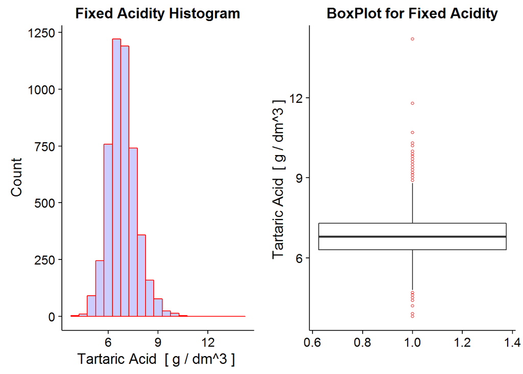

Bell shaped, a very small positive skewness.

## Volatile Acidity

This one is measured by the acetic acid’s concentration within the wine. At too high level, this will cause an unpleasant, vinegar like taste. We have 0 missing values.

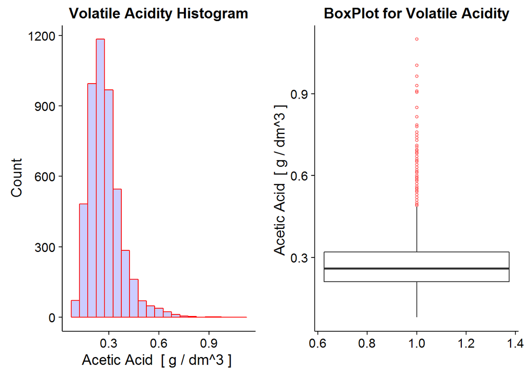

## Citric Acid

Found in small quantities, citric acid can dd frehness and flavor to wine. We have 0 missing values.

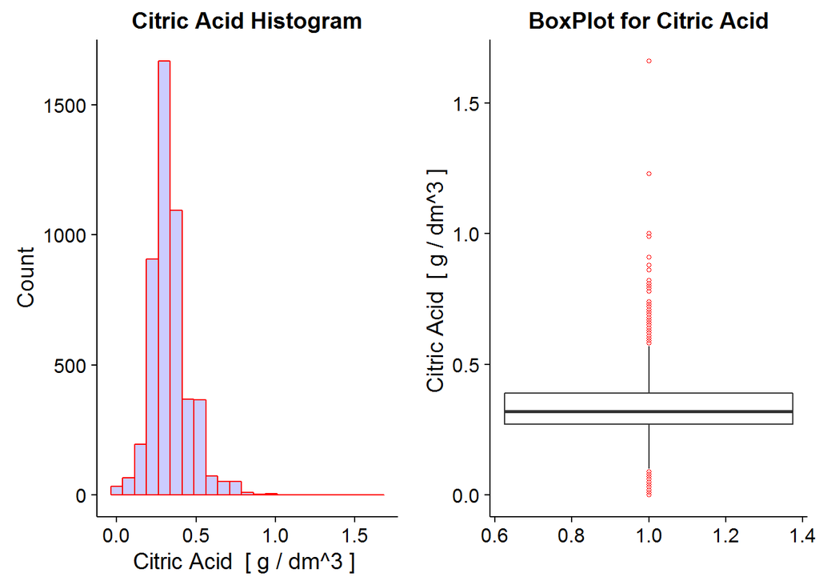

## Residual Sugar

The amount of sugar remaining after fermentation stops, it’s rare to find wines with less than 1 gram/liter and wines with greater than 45 grams/liter are considered sweet. We have 0 missing values.

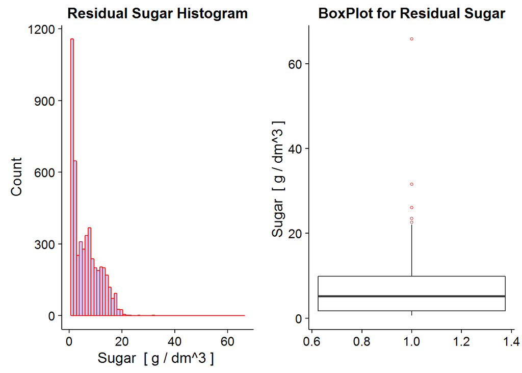

A bimodal shape here, with an extremely high spike at the start (Dry wine, no or very little residual sugar), then another smaller summit at roughly 8 g/dm^3

## Chlorides

The amount of salt in the wine. We have 0 missing values.

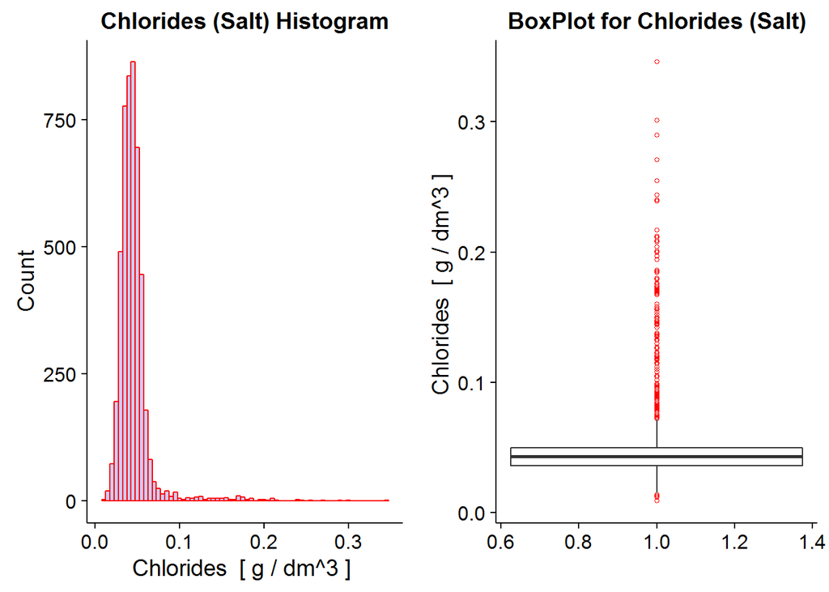

A lot of outliers in here. But the main bulk has a balanced bell shape.

## Free Sulfur Dioxide

The free form of SO2 exists in equilibrium between molecular SO2 (as a dissolved gas) and bisulfite ion; it prevents microbial growth and the oxidation of wine. At free SO2 concentrations over 50 ppm, SO2 becomes evident in the nose and taste of wine We have 0 missing values.

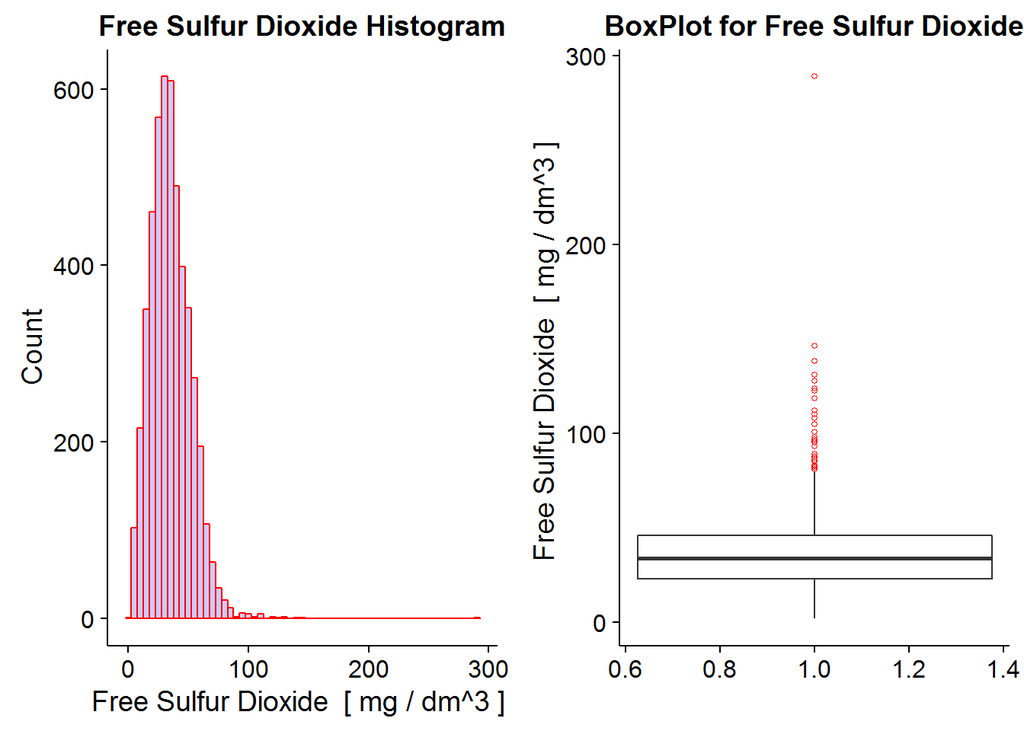

Same as chlorides, but the proportion of outliers here is a lot less.

## Total Sulfur Dioxide

Amount of free and bound forms of S02; in low concentrations, SO2 is mostly undetectable in wine, but at free SO2 concentrations over 50 ppm, SO2 becomes evident in the nose and taste of wine. We have 0 missing values.

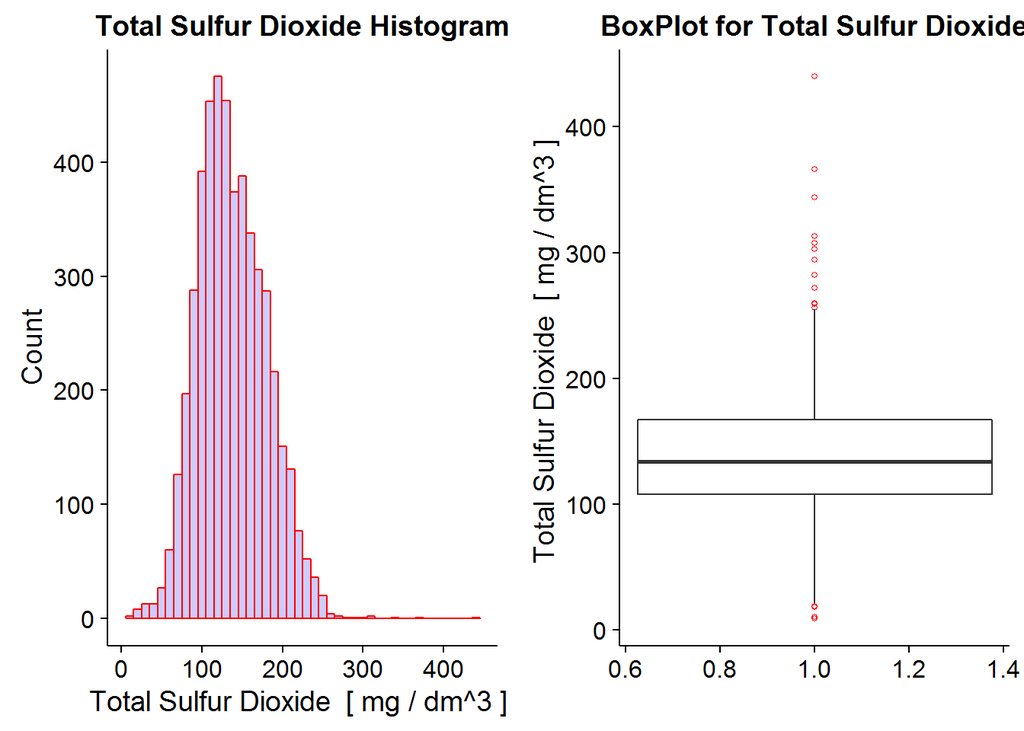

The outliers here are even less than that of the free sulfurs.

## Density

The density of water is close to that of water depending on the percent alcohol and sugar content. We have 0 missing values.

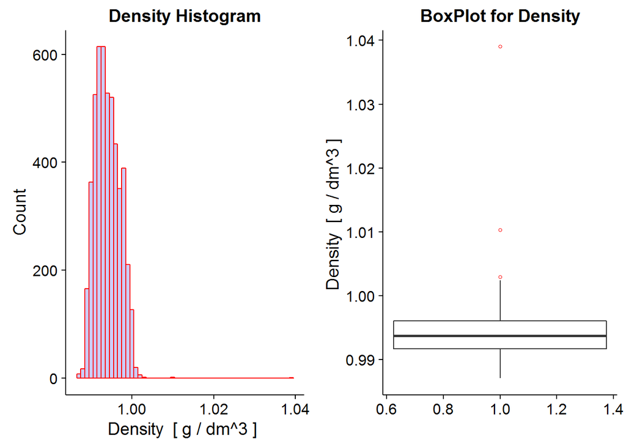

Very little outliers, and a very narrow density range (I mean numerically). The vast majority of the wines are just a tiny bit less dense than water.

## pH

Describes how acidic or basic a wine is on a scale from 0 (very acidic) to 14 (very basic); most wines are between 3-4 on the pH scale. We have 0 missing values.

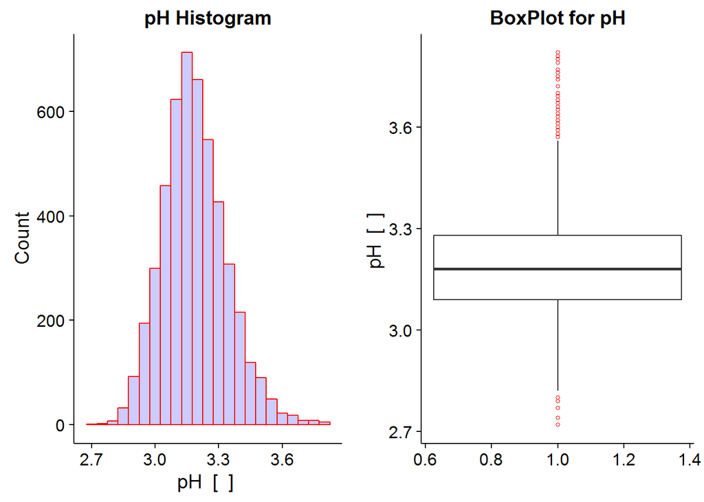

A classical bell shape, and all wines are within the acidic pH range with a mean pH around 3.2

## Sulphates

A wine additive which can contribute to sulfur dioxide gas (S02) levels, wich acts as an antimicrobial and antioxidant. We have 0 missing values.

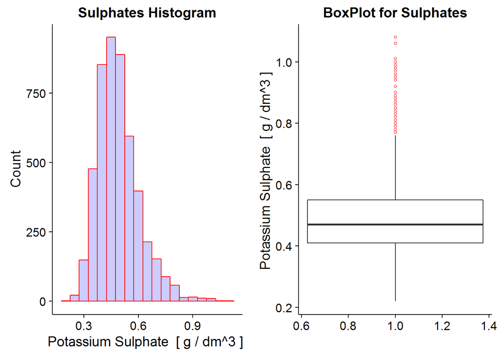

Positively skewed bell shape.

## Alcohol

The percent alcohol content of the wine. We have 0 missing values.

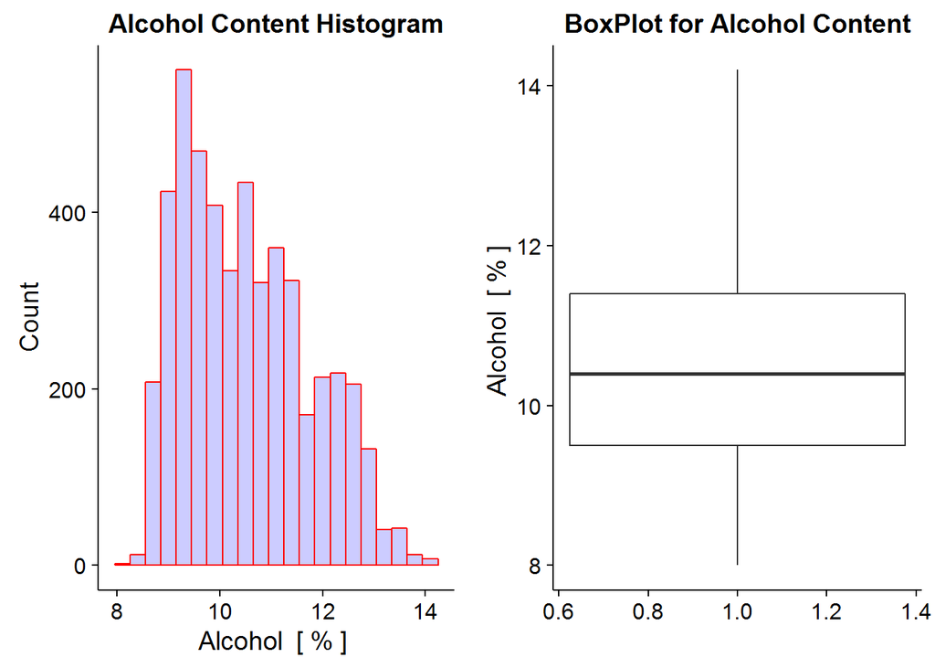

Alcohol distribution has a heavy positive skeweness. The peak is maybe at 9%, but the bulk of bottles have a higher alcohol rate.

## Quality Score

Expert Rating for the wine, on a scale from 1 to 10. We have 0 missing values.

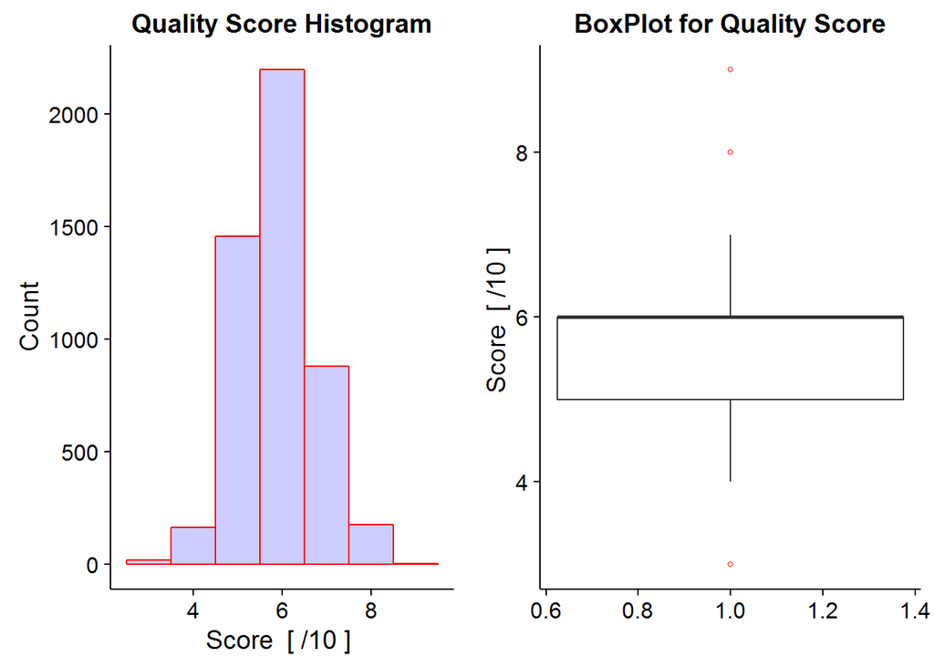

Minimum score is 3, maximum is 9. The most common score is 6, but there are more bottles with a worse score than not.

# Univariate Analysis

### What is the structure of your dataset?

The dataset has 11 variables describing - chemically - the wine, and one last variable for the wine’s quality as perceived by wine experts, graded from 0 (very bad) to 10 (highest quality). Each wine is was evaluated by at least 3 experts. As declared: “Due to privacy and logistic issues, only physicochemical (inputs) and sensory (the output) variables are available (e.g. there is no data about grape types, wine brand, wine selling price, etc.).”

I honestly would have wished to have the price tag as well.

### What is/are the main feature(s) of interest in your dataset?

From the univariable analysis, there is not really any striking variable. All of them have a - more or less - bell shape, with different levels of skewness. Intuitevly though, the most important factor would be the quality.

### What other features in the dataset do you think will help support your investigation into your feature(s) of interest?

I will wait for the correlation calculation to see which variables are most related to quality. I would suspect that acidity, sulfur contents and alcohol level would be important factors.

### Did you create any new variables from existing variables in the dataset?

Not yet

### Of the features you investigated, were there any unusual distributions? Did you perform any operations on the data to tidy, adjust, or change the form of the data? If so, why did you do this?

Alcohol was positively skewed in a very noticeable way, while quality was slightly negatively skewed. There is not a lot of outliers in the data.

# Bivariate Plots Section

## General Overview

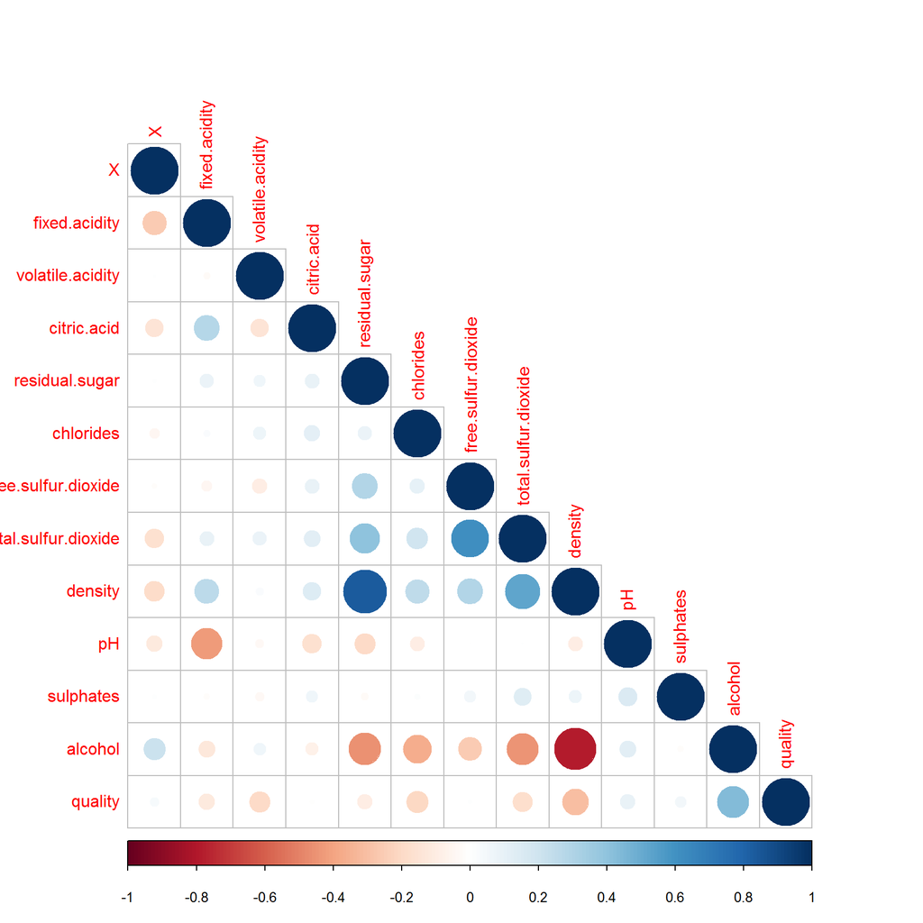

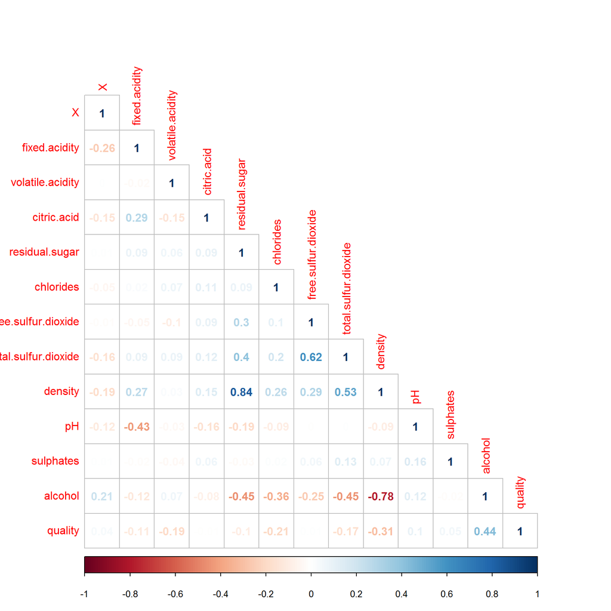

These graphs bring a lot of insight. From the quality stand point, the strongest correlation exists with the alcohol level. It is not surprising then that the strongest reverse correlation with quality is the density of the wine, since the alcohol level is a strong factor for density: the more alcohol we have, the lesser is the density.

## Density

Density seems to be affected by a lot of factors. It also seems that it is an important factor with quality, having an inverse relationship with it. The top elements affecting density are: 1- Residual Sugar 2- Alcohol 3- Total Sulfur Dioxide

### Density vs Residual Sugar

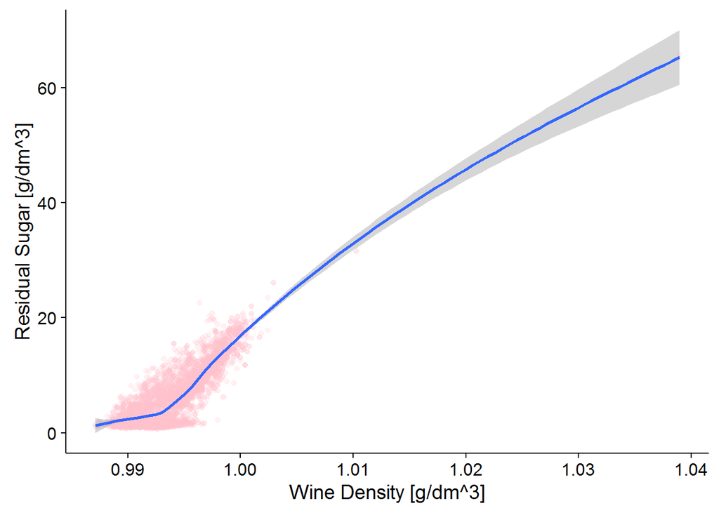

### Density vs Alcohol

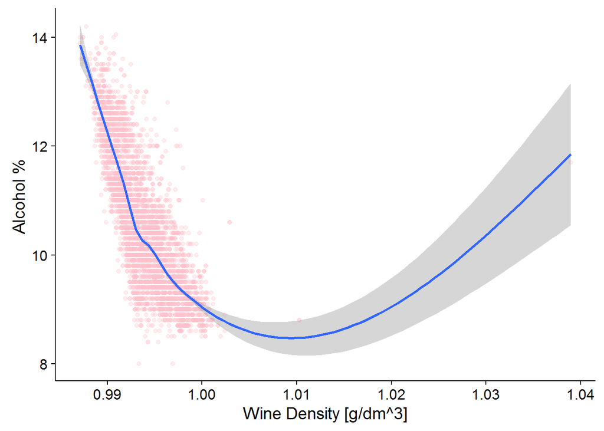

### Density vs Total Sulfur Dioxide

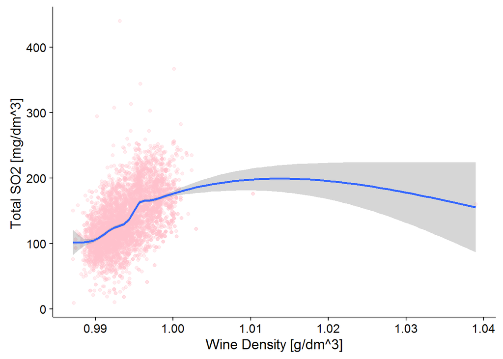

## Quality

### Enhancing Factor

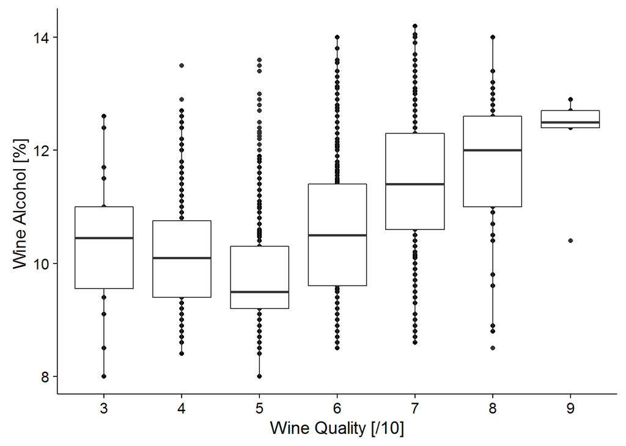

### Degrading Factors

#### Density

Density seems to be the most indicating factor about the quality (or lack of, since it is an inversly proportional relationship). It can seem immediately logical that this is just the reflection of the lack of alcohol - since alcohol is correlated with quality, and it reduces the wine’s density at the same time. But on the other hand, density is also affected by other factors, and so it should be a good parameter to observe:

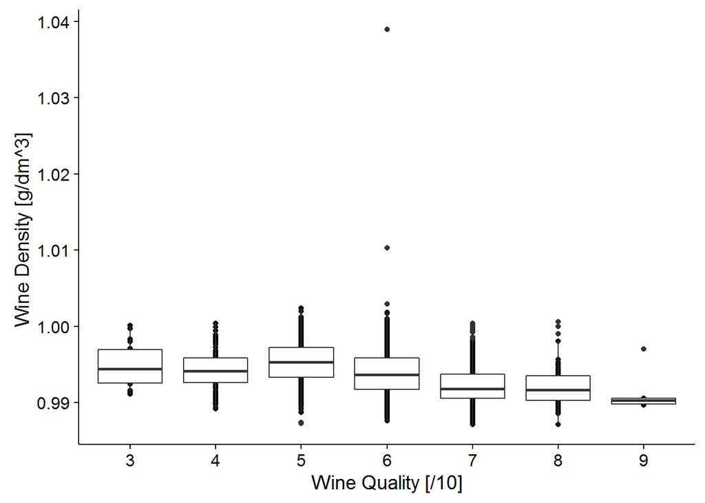

#### Other Factors

The top three degrading variables (By correlation) are Volatile Acidity, Chlorides and Total Sulfure Dioxide

**Volatile Acidity:**

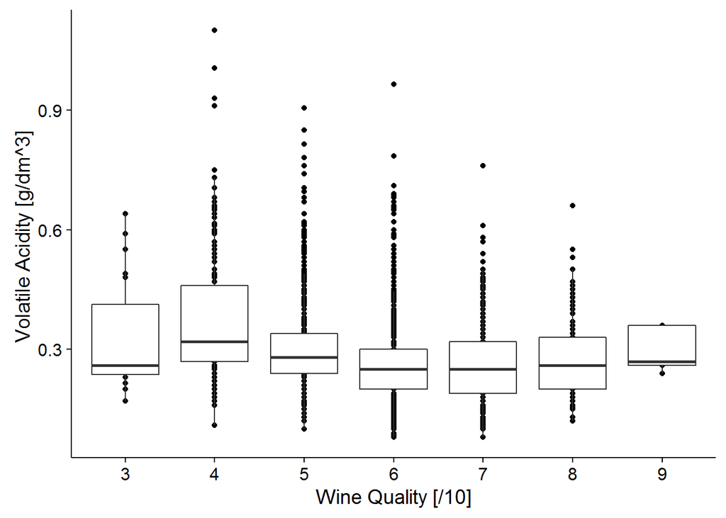

**Salts:**

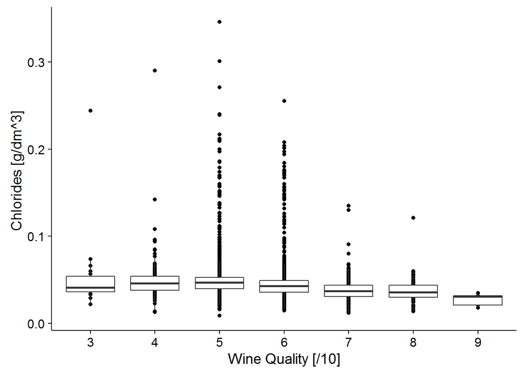

**Total Sulfur Dioxide:**

[figure not shown]

**Total of the three elements**

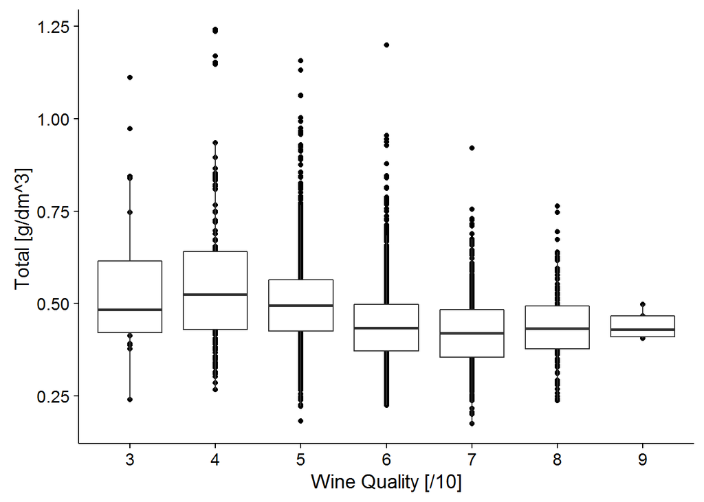

The two factors that I would like to further explore are the quality and alcohol content. These will be categorized each into three categories. For the quality, the three categories are:

- Low Quality (Scores 3 and 4)
- Medium Quality (Scores 5, 6 and 7)
- High Quality (Scores 8 and 9)

For the alcohol contents, the categories are:

- Low Alcohol (Under 10%)
- Medium Alcohol (Between 10% and 12%)
- High Alcohol (Over 12%)

These divisions are arbitrary, they are not based over how experts would categorize wine. The boundaries were based over balancing the number of bottles between each category. When I tried to look it up online, a high alcohol wine would be something above 14.5% for example, which would make such a categorisation useless since we do not have any bottles with such a high alcohol level (The highest here is 14.2%)

## Alcohol, a Categorised Perspective

### Residual Sugar

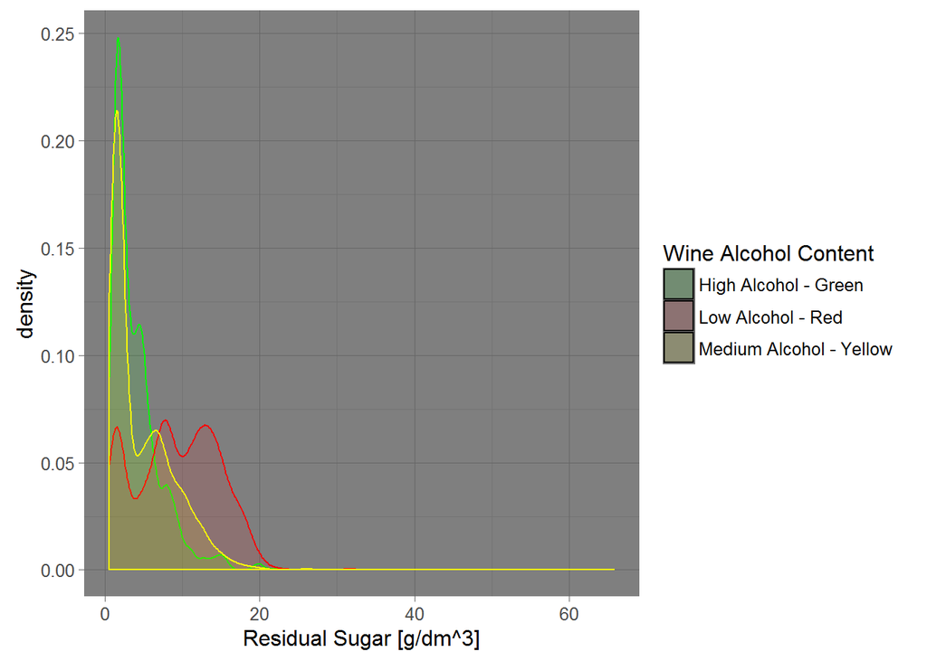

Sugar contents have an inverse correlation with the alcohol content.

### Total Sulfur Dioxide

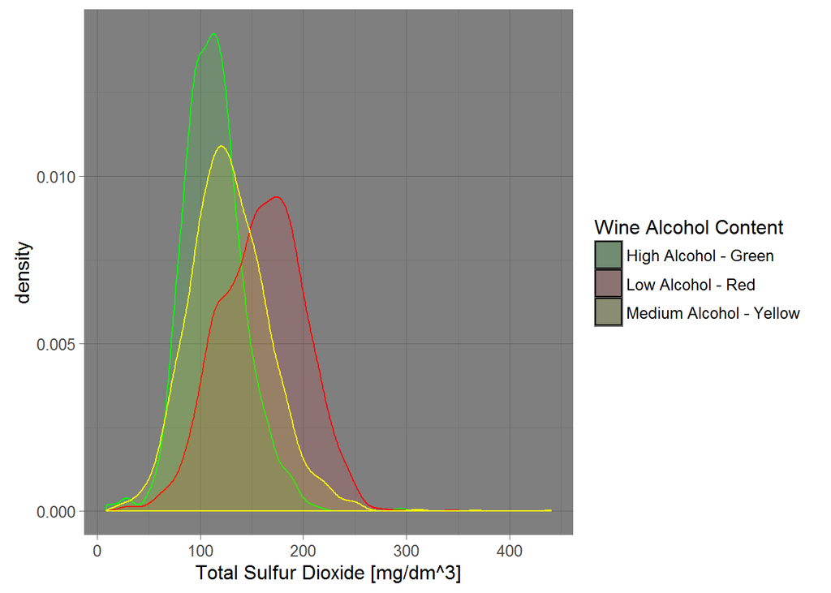

The lower the alcohol, the higher sulfur contents. Sulfur dioxide is a preservative, and so is alcohol. Maybe they add it when there is a low alcohol so that the wine would stay fresh for a longer time?

## Quality, a Categorized Perspective

### Saltiness and Quality

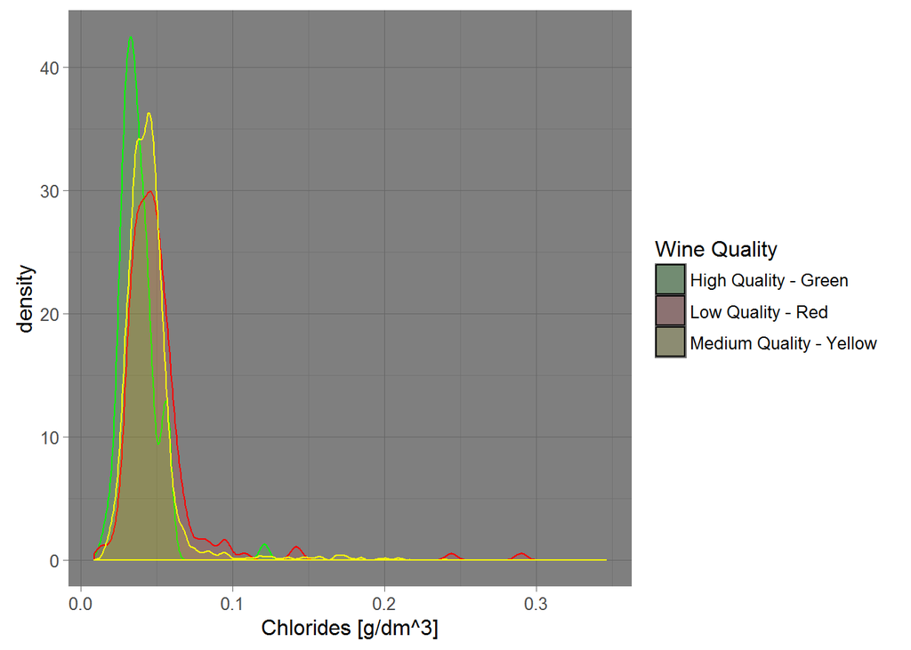

Not too surprising, but the trend here is: the lesser salt the better the taste.

### Acidity Effect Over Quality

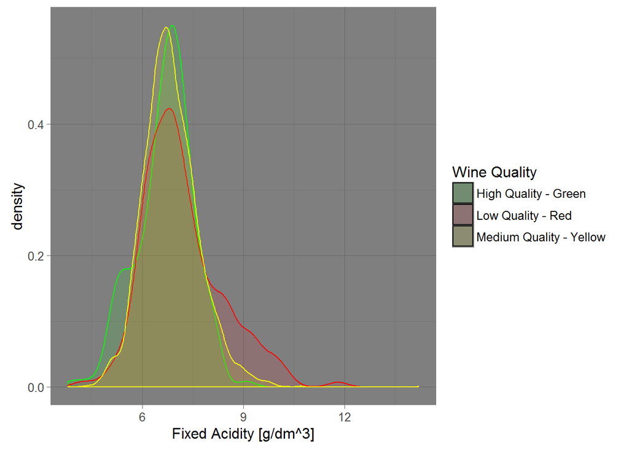

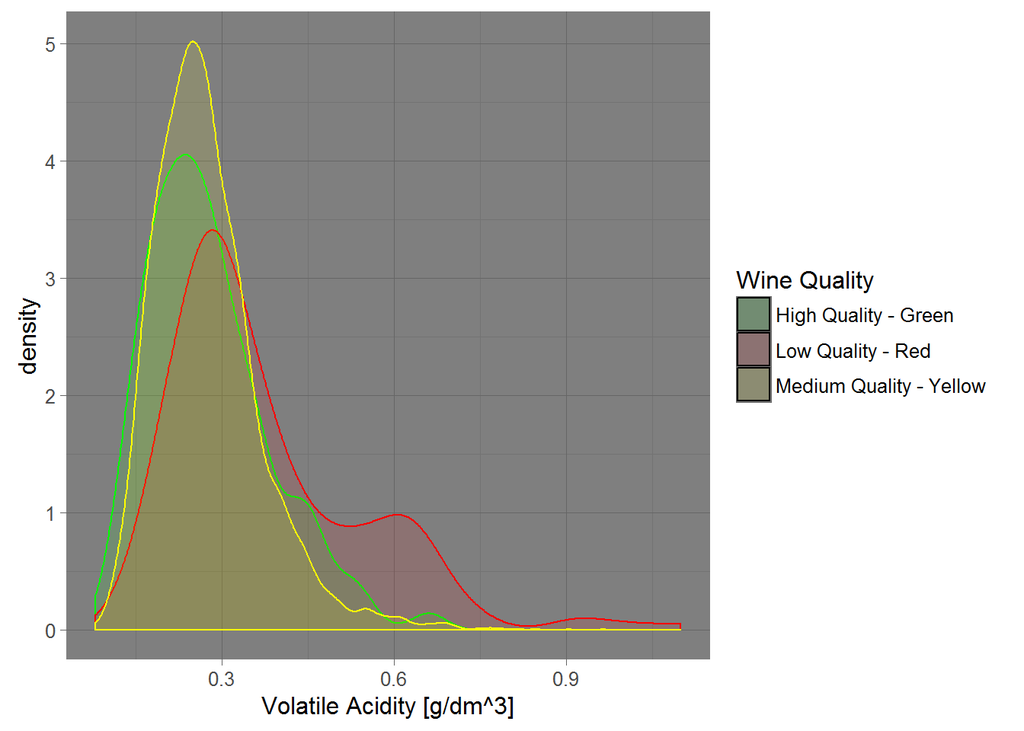

### Citric Acid and Quality

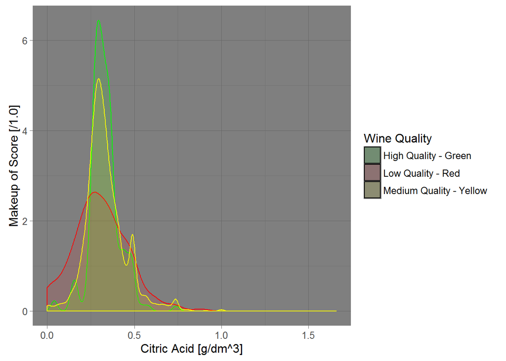

I have the impression that the citric acid contents has a narrow window to be the right amount. Too low or too high (Especially too low) is more trending in low quality wines. It is striking how the medium and high quality wines have similar shapes, around the same concentration.

## How Alcohol Categories are Ditributed Over Quality Score ?

The strong correlation between quality and alcohol is indeed the most interesting in my opinion so far. Let us explore the make up of each quality score in terms of wine alcohol category:

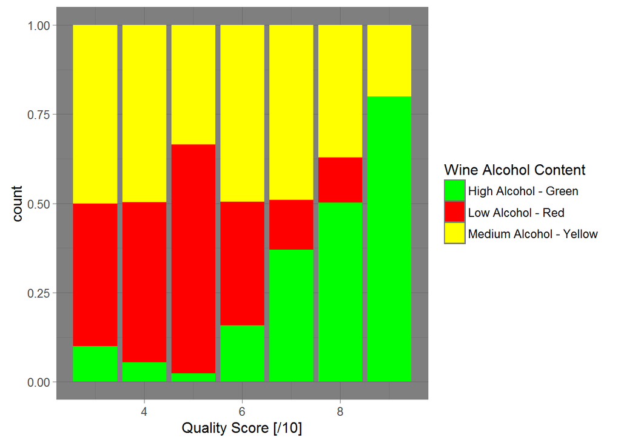

Medium alcohol is distributed all over, making up almost half the bottles for each score, except for the highest score. But since we have a lot more medium alcohol bottles than the two other categories, I will try to see the distribution of each type of alcohol content over all the scores. The y axis will represent the percentage in terms of each category independetly, not as a percentage of all the bottles. This normalization should reduce the effect of the different size of each alcohol category.

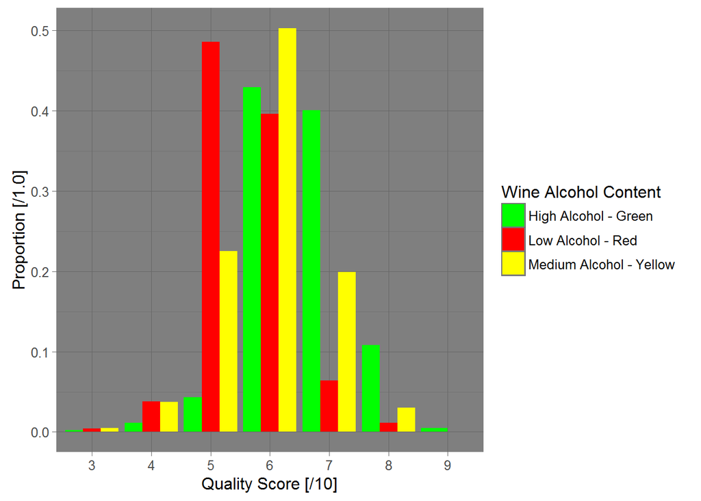

The distribution looks like a bell shape for all the alcohol categeries, even for the high alcohol ones. High alcohol is slightly leaning (skewed) towards the higher scores, and the medium alcohol is slightly leaning towards the lesser scores. The only decisive distribution is that of the low alcohol bottles, being heavily concentrated towards the lesser scores, and having its peak at score of 5 out of 10. Medium and high alcohol’s peak is at 6/10.

# Bivariate Analysis

### Talk about some of the relationships you observed in this part of the investigation. How did the feature(s) of interest vary with other features in the dataset?

Density, although its range of variation is narrow (All, more or less, are around the density of water), had a lot of correlations with different factors. Residual sugars, alcohol contents and total sulfur dioxide were the most defining factors.

Next, quality. Generally speaking, most factors had negative correlations with quality except for the alcohol level, and this makes sense. Excessive volatile acidity would give wine a vinegar like taste, chlorides make the wine salty and sulfur dioxide tastes like matches. So when any of these contents are high enough to a noticeable level, they would degrade the rating of the wine. For alcohol, I think this is an indirect relationship with quality though. Alcohol is a preservative, and its presence in good quantities reduces the need of adding other preservatives like sulfur dioxide. But of course this is not a conclusion driven from the data, it is just my intuition about it. Saltiness density distribution is remarkable, with the best qualities wines having a distribution with smaller salt concentration.

For acidity, all three quality categories had positive skewness. The more interesting factor of their density distribution shape was the kurtosis: low quality wine had the lowest kurtosis, but the kurtosis of the other two is a bit confusing: medium wine had the highest one, and not the high quality wine. More over, they had almost their summit around the same value. That gives me the impression that both fixed and volatile acidity are not a critical factor for quality, although that it had some of the highest correlation with quality (Not high coefficients on absolute scale, in fact these should be considered as weak correlations, but I mean in comparison with other factors). The last, and most interesting acidity factor in my opinion was the citric acid. Its kurtosis was really prominent, giving the impression that the right quantity was really within a narrow window, somewhere between 0.2 and a little less than 0.5 g/dm**3. Although the highest three degrading components - chlorides, volatile acidity and total sulfur dioxide - had correlations of -.21, -.195 and -.175 respectively, their total per volume had a stronger negative correlation (-.268). I have tried to explore more by creating different combinations of their ratios, but these did not lead to any significant correlation worth mentioning.

Finally, alcohol level. The relationship between alcohol and residual sugars is generally inversly proportional, but the interesting part of it is that for low alcohol wines, the density distribution was tri-modal. So a low alcohol wine can have sugar concentration all over the spectrum, while medium and high alcohol content wines are more leaning towards being less sweet. Alcohol and density are related, but that was something already expected, as alcohol has a lower density than water, so the more alcohol we have the less total density is going to be. Most ingredients had a negative correlation with alcohol, so the trend for alcohol is that the higher it is, the less the acidity, sweetness and saltiness of the wine.

### Did you observe any interesting relationships between the other features (not the main feature(s) of interest)?

Yes: pH was most affected by the fixed acidity (more than volatile acidity). In fact, I was surprised that the pH had an almost 0 correlation coefficient with volatile acidity. Sulphates and alcohol had a small positive correlation with pH.

### What was the strongest relationship you found?

Quality: Alcohol (coeff = .436) Density (coeff = -.307) Total of Chlorides, volatile acidity and total sulfur dioxide (-.268)